# R Notebook

Chapter 13  
Relational Data

13.1 multiple tables of data are called relational data because it is the relations, not just the individual datasets, that are important.

Mutating joins, which add new variables to one data frame from matching observations in another  
Filtering joins, which filter observations from one data frame based on whether or not they match an observation in the other table.  
Set operations, which treat observations as if they were set elements.

```r
library(tidyverse)
library(nycflights13)
```

```r
airlines
```

| carrier | name |
| --- | --- |
| 9E | Endeavor Air Inc. |
| AA | American Airlines Inc. |
| AS | Alaska Airlines Inc. |
| B6 | JetBlue Airways |
| DL | Delta Air Lines Inc. |
| EV | ExpressJet Airlines Inc. |
| F9 | Frontier Airlines Inc. |
| FL | AirTran Airways Corporation |
| HA | Hawaiian Airlines Inc. |
| MQ | Envoy Air |

[output cut: 6 more lines]

```r
airports
```

| faa | name | lat | lon | alt | tz | dst | tzone |
| --- | --- | --- | --- | --- | --- | --- | --- |
| 04G | Lansdowne Airport | 41.13047 | -80.61958 | 1044 | -5 | A | America/New_York |
| 06A | Moton Field Municipal Airport | 32.46057 | -85.68003 | 264 | -6 | A | America/Chicago |
| 06C | Schaumburg Regional | 41.98934 | -88.10124 | 801 | -6 | A | America/Chicago |
| 06N | Randall Airport | 41.43191 | -74.39156 | 523 | -5 | A | America/New_York |
| 09J | Jekyll Island Airport | 31.07447 | -81.42778 | 11 | -5 | A | America/New_York |
| 0A9 | Elizabethton Municipal Airport | 36.37122 | -82.17342 | 1593 | -5 | A | America/New_York |
| 0G6 | Williams County Airport | 41.46731 | -84.50678 | 730 | -5 | A | America/New_York |
| 0G7 | Finger Lakes Regional Airport | 42.88356 | -76.78123 | 492 | -5 | A | America/New_York |
| 0P2 | Shoestring Aviation Airfield | 39.79482 | -76.64719 | 1000 | -5 | U | America/New_York |
| 0S9 | Jefferson County Intl | 48.05381 | -122.81064 | 108 | -8 | A | America/Los_Angeles |

[output cut: 990 more lines]

```r
planes
```

| tailnum | year | type | manufacturer | model | engines | seats | speed | engine |
| --- | --- | --- | --- | --- | --- | --- | --- | --- |
| N10156 | 2004 | Fixed wing multi engine | EMBRAER | EMB-145XR | 2 | 55 | NA | Turbo-fan |
| N102UW | 1998 | Fixed wing multi engine | AIRBUS INDUSTRIE | A320-214 | 2 | 182 | NA | Turbo-fan |
| N103US | 1999 | Fixed wing multi engine | AIRBUS INDUSTRIE | A320-214 | 2 | 182 | NA | Turbo-fan |
| N104UW | 1999 | Fixed wing multi engine | AIRBUS INDUSTRIE | A320-214 | 2 | 182 | NA | Turbo-fan |
| N10575 | 2002 | Fixed wing multi engine | EMBRAER | EMB-145LR | 2 | 55 | NA | Turbo-fan |
| N105UW | 1999 | Fixed wing multi engine | AIRBUS INDUSTRIE | A320-214 | 2 | 182 | NA | Turbo-fan |
| N107US | 1999 | Fixed wing multi engine | AIRBUS INDUSTRIE | A320-214 | 2 | 182 | NA | Turbo-fan |
| N108UW | 1999 | Fixed wing multi engine | AIRBUS INDUSTRIE | A320-214 | 2 | 182 | NA | Turbo-fan |
| N109UW | 1999 | Fixed wing multi engine | AIRBUS INDUSTRIE | A320-214 | 2 | 182 | NA | Turbo-fan |
| N110UW | 1999 | Fixed wing multi engine | AIRBUS INDUSTRIE | A320-214 | 2 | 182 | NA | Turbo-fan |

[output cut: 990 more lines]

```r
weather
```

| origin | year | month | day | hour | temp | dewp | humid | wind_dir | wind_speed | wind_gust | precip | pressure | visib | time_hour |
| --- | --- | --- | --- | --- | --- | --- | --- | --- | --- | --- | --- | --- | --- | --- |
| EWR | 2013 | 1 | 1 | 1 | 39.02 | 26.06 | 59.37 | 270 | 10.35702 | NA | 0.00 | 1012.0 | 10.00 | 2013-01-01 01:00:00 |
| EWR | 2013 | 1 | 1 | 2 | 39.02 | 26.96 | 61.63 | 250 | 8.05546 | NA | 0.00 | 1012.3 | 10.00 | 2013-01-01 02:00:00 |
| EWR | 2013 | 1 | 1 | 3 | 39.02 | 28.04 | 64.43 | 240 | 11.50780 | NA | 0.00 | 1012.5 | 10.00 | 2013-01-01 03:00:00 |
| EWR | 2013 | 1 | 1 | 4 | 39.92 | 28.04 | 62.21 | 250 | 12.65858 | NA | 0.00 | 1012.2 | 10.00 | 2013-01-01 04:00:00 |
| EWR | 2013 | 1 | 1 | 5 | 39.02 | 28.04 | 64.43 | 260 | 12.65858 | NA | 0.00 | 1011.9 | 10.00 | 2013-01-01 05:00:00 |
| EWR | 2013 | 1 | 1 | 6 | 37.94 | 28.04 | 67.21 | 240 | 11.50780 | NA | 0.00 | 1012.4 | 10.00 | 2013-01-01 06:00:00 |
| EWR | 2013 | 1 | 1 | 7 | 39.02 | 28.04 | 64.43 | 240 | 14.96014 | NA | 0.00 | 1012.2 | 10.00 | 2013-01-01 07:00:00 |
| EWR | 2013 | 1 | 1 | 8 | 39.92 | 28.04 | 62.21 | 250 | 10.35702 | NA | 0.00 | 1012.2 | 10.00 | 2013-01-01 08:00:00 |
| EWR | 2013 | 1 | 1 | 9 | 39.92 | 28.04 | 62.21 | 260 | 14.96014 | NA | 0.00 | 1012.7 | 10.00 | 2013-01-01 09:00:00 |
| EWR | 2013 | 1 | 1 | 10 | 41.00 | 28.04 | 59.65 | 260 | 13.80936 | NA | 0.00 | 1012.4 | 10.00 | 2013-01-01 10:00:00 |

[output cut: 990 more lines]

To connect each plane to its origin you would need to combine the flights and airports tables.  
If weather was included with all aiports, it would show weather info at departing and arriving aiports of a flight.  
You could add “special” days as a column of holidays and have a holidays table in the data.

13.3

A key is a variable (or set of variables) that uniquely identifies an observation  
- these connect tables

A primary key uniquely identifies an observation in its own table.  
A foreign key uniquely identifies an observation in another table.

Surrogate key is one that can be added if primary key is missing.

13.4

A mutating join allows you to combine variables from two tables.

```r
flights2 <- flights %>%
  select(year:day, hour, origin, dest, tailnum, carrier)
flights2
```

| year | month | day | hour | origin | dest | tailnum | carrier |
| --- | --- | --- | --- | --- | --- | --- | --- |
| 2013 | 1 | 1 | 5 | EWR | IAH | N14228 | UA |
| 2013 | 1 | 1 | 5 | LGA | IAH | N24211 | UA |
| 2013 | 1 | 1 | 5 | JFK | MIA | N619AA | AA |
| 2013 | 1 | 1 | 5 | JFK | BQN | N804JB | B6 |
| 2013 | 1 | 1 | 6 | LGA | ATL | N668DN | DL |
| 2013 | 1 | 1 | 5 | EWR | ORD | N39463 | UA |
| 2013 | 1 | 1 | 6 | EWR | FLL | N516JB | B6 |
| 2013 | 1 | 1 | 6 | LGA | IAD | N829AS | EV |
| 2013 | 1 | 1 | 6 | JFK | MCO | N593JB | B6 |
| 2013 | 1 | 1 | 6 | LGA | ORD | N3ALAA | AA |

[output cut: 990 more lines]

```r
flights2 %>%
  select(-origin, -dest) %>%
  left_join(airlines, by = "carrier")
```

```
`chr_along()` is deprecated as of rlang 0.2.0.
```

| year | month | day | hour | tailnum | carrier | name |
| --- | --- | --- | --- | --- | --- | --- |
| 2013 | 1 | 1 | 5 | N14228 | UA | United Air Lines Inc. |
| 2013 | 1 | 1 | 5 | N24211 | UA | United Air Lines Inc. |
| 2013 | 1 | 1 | 5 | N619AA | AA | American Airlines Inc. |
| 2013 | 1 | 1 | 5 | N804JB | B6 | JetBlue Airways |
| 2013 | 1 | 1 | 6 | N668DN | DL | Delta Air Lines Inc. |
| 2013 | 1 | 1 | 5 | N39463 | UA | United Air Lines Inc. |
| 2013 | 1 | 1 | 6 | N516JB | B6 | JetBlue Airways |
| 2013 | 1 | 1 | 6 | N829AS | EV | ExpressJet Airlines Inc. |
| 2013 | 1 | 1 | 6 | N593JB | B6 | JetBlue Airways |
| 2013 | 1 | 1 | 6 | N3ALAA | AA | American Airlines Inc. |

[output cut: 990 more lines]

An inner join matches pairs of observations whenever their keys are equal.  
An outer join keeps observations that appear in at least one of the tables.

```r
flights2 %>%
  left_join(weather)
```

| year | month | day | hour | origin | dest | tailnum | carrier | temp | dewp | humid | wind_dir | wind_speed | wind_gust | precip | pressure | visib | time_hour |
| --- | --- | --- | --- | --- | --- | --- | --- | --- | --- | --- | --- | --- | --- | --- | --- | --- | --- |
| 2013 | 1 | 1 | 5 | EWR | IAH | N14228 | UA | 39.02 | 28.04 | 64.43 | 260 | 12.65858 | NA | 0 | 1011.9 | 10 | 2013-01-01 05:00:00 |
| 2013 | 1 | 1 | 5 | LGA | IAH | N24211 | UA | 39.92 | 24.98 | 54.81 | 250 | 14.96014 | 21.86482 | 0 | 1011.4 | 10 | 2013-01-01 05:00:00 |
| 2013 | 1 | 1 | 5 | JFK | MIA | N619AA | AA | 39.02 | 26.96 | 61.63 | 260 | 14.96014 | NA | 0 | 1012.1 | 10 | 2013-01-01 05:00:00 |
| 2013 | 1 | 1 | 5 | JFK | BQN | N804JB | B6 | 39.02 | 26.96 | 61.63 | 260 | 14.96014 | NA | 0 | 1012.1 | 10 | 2013-01-01 05:00:00 |
| 2013 | 1 | 1 | 6 | LGA | ATL | N668DN | DL | 39.92 | 24.98 | 54.81 | 260 | 16.11092 | 23.01560 | 0 | 1011.7 | 10 | 2013-01-01 06:00:00 |
| 2013 | 1 | 1 | 5 | EWR | ORD | N39463 | UA | 39.02 | 28.04 | 64.43 | 260 | 12.65858 | NA | 0 | 1011.9 | 10 | 2013-01-01 05:00:00 |
| 2013 | 1 | 1 | 6 | EWR | FLL | N516JB | B6 | 37.94 | 28.04 | 67.21 | 240 | 11.50780 | NA | 0 | 1012.4 | 10 | 2013-01-01 06:00:00 |
| 2013 | 1 | 1 | 6 | LGA | IAD | N829AS | EV | 39.92 | 24.98 | 54.81 | 260 | 16.11092 | 23.01560 | 0 | 1011.7 | 10 | 2013-01-01 06:00:00 |
| 2013 | 1 | 1 | 6 | JFK | MCO | N593JB | B6 | 37.94 | 26.96 | 64.29 | 260 | 13.80936 | NA | 0 | 1012.6 | 10 | 2013-01-01 06:00:00 |
| 2013 | 1 | 1 | 6 | LGA | ORD | N3ALAA | AA | 39.92 | 24.98 | 54.81 | 260 | 16.11092 | 23.01560 | 0 | 1011.7 | 10 | 2013-01-01 06:00:00 |

[output cut: 990 more lines]

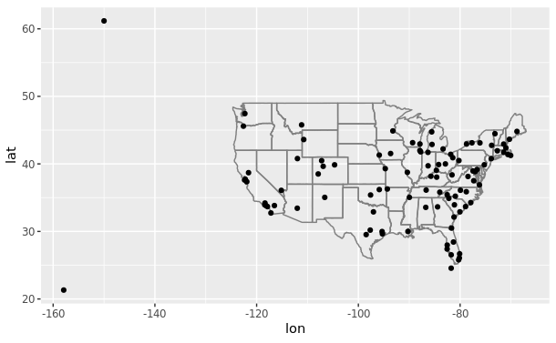

```r
airports %>%
  semi_join(flights, c("faa" = "dest")) %>%
  ggplot(aes(lon, lat)) +
    borders("state") +
    geom_point() +
    coord_quickmap()
```

```r
flights %>%
  filter(is.na(tailnum), !is.na(arr_time)) %>%
  nrow()
```

```
[1] 0
```

Flights with bo tail number means that that flight was cancelled.

13.7 Set operations work with a complete row, comparing the values of every variable.